# Credit Risk Assessment with Logistic Regression

- Show All Code
- Hide All Code
- View Source

Author

Kevin Kimurgor

```r
library(tidyverse)
library(caret)
library(car)
```

```r
loan <- read.csv("C:\\Users\\USER\\Downloads\\loan_data.csv")
```

```r
str(loan)
```

```
'data.frame':   45000 obs. of  14 variables:
 $ person_age                    : num  22 21 25 23 24 21 26 24 24 21 ...
 $ person_gender                 : chr  "female" "female" "female" "female" ...
 $ person_education              : chr  "Master" "High School" "High School" "Bachelor" ...
 $ person_income                 : num  71948 12282 12438 79753 66135 ...
 $ person_emp_exp                : int  0 0 3 0 1 0 1 5 3 0 ...
 $ person_home_ownership         : chr  "RENT" "OWN" "MORTGAGE" "RENT" ...
 $ loan_amnt                     : num  35000 1000 5500 35000 35000 2500 35000 35000 35000 1600 ...
 $ loan_intent                   : chr  "PERSONAL" "EDUCATION" "MEDICAL" "MEDICAL" ...
 $ loan_int_rate                 : num  16 11.1 12.9 15.2 14.3 ...
 $ loan_percent_income           : num  0.49 0.08 0.44 0.44 0.53 0.19 0.37 0.37 0.35 0.13 ...
 $ cb_person_cred_hist_length    : num  3 2 3 2 4 2 3 4 2 3 ...
 $ credit_score                  : int  561 504 635 675 586 532 701 585 544 640 ...
 $ previous_loan_defaults_on_file: chr  "No" "Yes" "No" "No" ...
 $ loan_status                   : int  1 0 1 1 1 1 1 1 1 1 ...
```

```r
dim(loan)
```

```
[1] 45000    14
```

```r
#data cleaning
sum(duplicated(loan))
```

```
[1] 0
```

```r
sum(is.na(loan))
```

```
[1] 0
```

```r
#convert all character data type to factors
loan <- loan |>
  mutate(across(where(is.character),factor))
#convert loan_status to factor (the target variable)
loan$loan_status <- as.factor(loan$loan_status)
str(loan)
```

```
'data.frame':   45000 obs. of  14 variables:
 $ person_age                    : num  22 21 25 23 24 21 26 24 24 21 ...
 $ person_gender                 : Factor w/ 2 levels "female","male": 1 1 1 1 2 1 1 1 1 1 ...
 $ person_education              : Factor w/ 5 levels "Associate","Bachelor",..: 5 4 4 2 5 4 2 4 1 4 ...
 $ person_income                 : num  71948 12282 12438 79753 66135 ...
 $ person_emp_exp                : int  0 0 3 0 1 0 1 5 3 0 ...
 $ person_home_ownership         : Factor w/ 4 levels "MORTGAGE","OTHER",..: 4 3 1 4 4 3 4 4 4 3 ...
 $ loan_amnt                     : num  35000 1000 5500 35000 35000 2500 35000 35000 35000 1600 ...
 $ loan_intent                   : Factor w/ 6 levels "DEBTCONSOLIDATION",..: 5 2 4 4 4 6 2 4 5 6 ...
 $ loan_int_rate                 : num  16 11.1 12.9 15.2 14.3 ...
 $ loan_percent_income           : num  0.49 0.08 0.44 0.44 0.53 0.19 0.37 0.37 0.35 0.13 ...
 $ cb_person_cred_hist_length    : num  3 2 3 2 4 2 3 4 2 3 ...
 $ credit_score                  : int  561 504 635 675 586 532 701 585 544 640 ...
 $ previous_loan_defaults_on_file: Factor w/ 2 levels "No","Yes": 1 2 1 1 1 1 1 1 1 1 ...
 $ loan_status                   : Factor w/ 2 levels "0","1": 2 1 2 2 2 2 2 2 2 2 ...
```

statistical models understand factors better e.g glm() ,lm () hence the need for conversion

```r
levels(loan$loan_status)
```

```
[1] "0" "1"
```

```r
# recode factor variable loan_status i.e 1 = "approved" 0 = "rejected"
loan <- loan |>
  mutate(loan_status = dplyr::recode(loan_status,
                              "1" = "approved",
                              "0" = "rejected")) |>
  mutate(loan_status = factor(loan_status, levels = c("rejected", "approved")))
```

```r
#split the data into training and test data. implementing an 80 20 split
set.seed(1999)  #useful for reproducibility
index <- createDataPartition(loan$loan_status,p=0.8,list = FALSE)
training_data <- loan[index,]
test_data <- loan[-index,]
```

```r
ctrl <- trainControl(method = "cv",number = 10)
```

To ensure that the model generalizes well to unseen data, I implemented **10-fold cross-validation** during training. This technique splits the training set into 10 equal parts, using 9 parts for training and 1 part for validation in each iteration. The process is repeated 10 times, and the performance is averaged.

Cross-validation helps reduce the risk of overfitting and provides a more **reliable estimate** of model performance than a single train/test split. It also ensures that all training data points are used for both training and validation at different stages.

```r
#building a logistic regression model
model <- glm(loan_status ~ ., family= binomial,data = training_data)
vif(model)
```

```
                                    GVIF Df GVIF^(1/(2*Df))
person_age                     15.577071  1        3.946780
person_gender                   1.001726  1        1.000863
person_education                1.084633  4        1.010207
person_income                   1.294122  1        1.137595
person_emp_exp                 12.384624  1        3.519179
person_home_ownership           1.162317  3        1.025386
loan_amnt                       2.173479  1        1.474272
loan_intent                     1.062820  5        1.006111
loan_int_rate                   1.116582  1        1.056684
loan_percent_income             2.237218  1        1.495733
cb_person_cred_hist_length      4.178976  1        2.044255
credit_score                    1.122011  1        1.059250
previous_loan_defaults_on_file  1.000000  1        1.000000
```

Implemented variation inflation factor (VIF) to check for multicollinearity.

person’s age and person’s employment experience have moderate to high correlation with other predictors

```r
cor(training_data$person_age, training_data$person_emp_exp, use = "complete.obs")
```

```
[1] 0.954658
```

A correlation of 0.955 is very strong this indicates extreme multicollinearity.

```r
model <- glm(loan_status~.-person_emp_exp,data = training_data,family = binomial)
```

I opted to remove person_emp_exp manually in the model.

```r
reduced_model <- step(model,direction = "backward")
```

```
Start:  AIC=15946.93
loan_status ~ (person_age + person_gender + person_education +
    person_income + person_emp_exp + person_home_ownership +
    loan_amnt + loan_intent + loan_int_rate + loan_percent_income +
    cb_person_cred_hist_length + credit_score + previous_loan_defaults_on_file) -
    person_emp_exp
```

```
                                 Df Deviance   AIC
- person_education                4    15905 15941
- cb_person_cred_hist_length      1    15903 15945
- person_gender                   1    15903 15945
- person_age                      1    15903 15945
<none>                                 15903 15947
- person_income                   1    15905 15947
- loan_amnt                       1    16212 16254
- credit_score                    1    16294 16336
- loan_intent                     5    16389 16423
- person_home_ownership           3    16587 16625
- loan_percent_income             1    17278 17320
- loan_int_rate                   1    18551 18593
- previous_loan_defaults_on_file  1    25875 25917

Step:  AIC=15941.03
loan_status ~ person_age + person_gender + person_income + person_home_ownership +
    loan_amnt + loan_intent + loan_int_rate + loan_percent_income +
    cb_person_cred_hist_length + credit_score + previous_loan_defaults_on_file
```

```
                                 Df Deviance   AIC
- cb_person_cred_hist_length      1    15905 15939
- person_gender                   1    15905 15939
- person_age                      1    15906 15940
<none>                                 15905 15941
- person_income                   1    15907 15941
- loan_amnt                       1    16214 16248
- credit_score                    1    16319 16353
- loan_intent                     5    16391 16417
- person_home_ownership           3    16588 16618
- loan_percent_income             1    17281 17315
- loan_int_rate                   1    18555 18589
- previous_loan_defaults_on_file  1    25878 25912

Step:  AIC=15939.19
loan_status ~ person_age + person_gender + person_income + person_home_ownership +
    loan_amnt + loan_intent + loan_int_rate + loan_percent_income +
    credit_score + previous_loan_defaults_on_file
```

```
                                 Df Deviance   AIC
- person_gender                   1    15906 15938
- person_age                      1    15906 15938
<none>                                 15905 15939
- person_income                   1    15908 15940
- loan_amnt                       1    16214 16246
- credit_score                    1    16319 16351
- loan_intent                     5    16391 16415
- person_home_ownership           3    16588 16616
- loan_percent_income             1    17281 17313
- loan_int_rate                   1    18555 18587
- previous_loan_defaults_on_file  1    25878 25910

Step:  AIC=15937.47
loan_status ~ person_age + person_income + person_home_ownership +
    loan_amnt + loan_intent + loan_int_rate + loan_percent_income +
    credit_score + previous_loan_defaults_on_file
```

```
                                 Df Deviance   AIC
- person_age                      1    15906 15936
<none>                                 15906 15938
- person_income                   1    15908 15938
- loan_amnt                       1    16214 16244
- credit_score                    1    16319 16349
- loan_intent                     5    16391 16413
- person_home_ownership           3    16589 16615
- loan_percent_income             1    17281 17311
- loan_int_rate                   1    18555 18585
- previous_loan_defaults_on_file  1    25878 25908

Step:  AIC=15935.94
loan_status ~ person_income + person_home_ownership + loan_amnt +
    loan_intent + loan_int_rate + loan_percent_income + credit_score +
    previous_loan_defaults_on_file
```

```
                                 Df Deviance   AIC
<none>                                 15906 15936
- person_income                   1    15909 15937
- loan_amnt                       1    16215 16243
- credit_score                    1    16332 16360
- loan_intent                     5    16394 16414
- person_home_ownership           3    16589 16613
- loan_percent_income             1    17281 17309
- loan_int_rate                   1    18556 18584
- previous_loan_defaults_on_file  1    25878 25906
```

## Feature Selection Using Backward Stepwise Selection

To improve model simplicity and interpretability, I applied **backward stepwise selection** using the step() function. This approach begins with the full model (excluded person_emp_exp) and iteratively removes the least useful variables — those that do not significantly contribute to model performance based on the **Akaike Information Criterion (AIC)**.

AIC balances model fit. it penalizes unnecessary predictors that do not improve the model meaningfully. The goal is to identify a model that explains the data well while avoiding overfitting.

Backward selection was preferred over forward selection in this case because it evaluates the full model first and eliminates predictors with minimal contribution.

```r
# Fit model using training data with selected features from the reduced model
final_model <- train(
  formula(reduced_model),
  data = training_data,
  method = "glm",
  family= binomial,
  trControl = ctrl
)
```

Using train enables me to apply 10 fold cross validation as set in ctrl. To also get results of the confusion matrix.

```r
summary(final_model)
```

```
Call:
NULL

Coefficients:
                                    Estimate Std. Error z value Pr(>|z|)
(Intercept)                        6.402e-02  2.912e-01   0.220    0.826
person_income                      4.652e-07  2.131e-07   2.183    0.029 *
person_home_ownershipOTHER         3.001e-01  3.466e-01   0.866    0.387
person_home_ownershipOWN          -1.394e+00  1.146e-01 -12.160  < 2e-16 ***
person_home_ownershipRENT          7.517e-01  4.497e-02  16.715  < 2e-16 ***
loan_amnt                         -9.801e-05  4.426e-06 -22.145  < 2e-16 ***
loan_intentEDUCATION              -9.165e-01  6.523e-02 -14.051  < 2e-16 ***
loan_intentHOMEIMPROVEMENT        -3.439e-03  7.371e-02  -0.047    0.963
loan_intentMEDICAL                -3.118e-01  6.321e-02  -4.932 8.12e-07 ***
loan_intentPERSONAL               -6.927e-01  6.680e-02 -10.369  < 2e-16 ***
loan_intentVENTURE                -1.208e+00  7.116e-02 -16.975  < 2e-16 ***
loan_int_rate                      3.380e-01  7.368e-03  45.873  < 2e-16 ***
loan_percent_income                1.564e+01  3.441e-01  45.446  < 2e-16 ***
credit_score                      -8.776e-03  4.360e-04 -20.127  < 2e-16 ***
previous_loan_defaults_on_fileYes -2.034e+01  1.149e+02  -0.177    0.860
---
Signif. codes:  0 '***' 0.001 '**' 0.01 '*' 0.05 '.' 0.1 ' ' 1

(Dispersion parameter for binomial family taken to be 1)

    Null deviance: 38139  on 35999  degrees of freedom
Residual deviance: 15906  on 35985  degrees of freedom
AIC: 15936

Number of Fisher Scoring iterations: 19
```

```r
#Predicted Class ( "Approved"/"Rejected")
class_predictions <- predict(final_model,newdata = test_data,type = "raw")
```

type = “raw” returns class labels as approved rejected. Using `caret::predict()` on a classification model like logistic regression, applies a 0.5 threshold on probabilties by default to classify outcomes.

```r
 #Predicted Probabilities (for ROC)
prob_predictions <- predict(final_model, newdata = test_data, type = "prob")

#positive class is "Approved"
approved_probs <- prob_predictions$approved
```

```r
confusionMatrix(
  data = class_predictions,
  reference = test_data$loan_status,
  positive = "approved"
)
```

```
Confusion Matrix and Statistics

          Reference
Prediction rejected approved
  rejected     6591      531
  approved      409     1469

               Accuracy : 0.8956
                 95% CI : (0.8891, 0.9018)
    No Information Rate : 0.7778
    P-Value [Acc > NIR] : < 2.2e-16

                  Kappa : 0.6911

 Mcnemar's Test P-Value : 7.927e-05

            Sensitivity : 0.7345
            Specificity : 0.9416
         Pos Pred Value : 0.7822
         Neg Pred Value : 0.9254
             Prevalence : 0.2222
         Detection Rate : 0.1632
   Detection Prevalence : 0.2087
      Balanced Accuracy : 0.8380

       'Positive' Class : approved
```

### Model Evaluation

The final logistic regression model was evaluated using a hold-out test set. The confusion matrix showed an accuracy of **89.6%**, with a **sensitivity of 73.5%** and **specificity of 94.2%**, indicating that the model performs well in detecting both approved and rejected loans.

The **Kappa score of 0.69** suggests substantial agreement beyond chance, while the **balanced accuracy of 83.8%** further confirms that the model handles class imbalance reasonably well. Although the McNemar’s test was significant (p < 0.001), suggesting some asymmetry in errors, the overall model performance is acceptable for a baseline logistic regression.

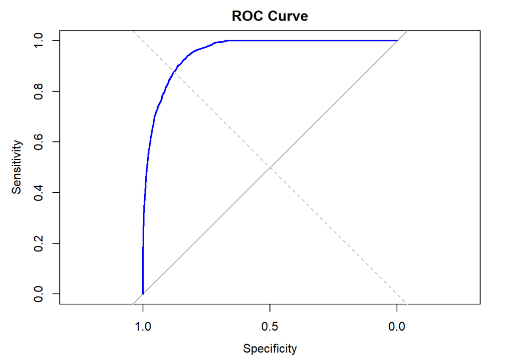

```r
# Load pROC for ROC curve
library(pROC)

# Create ROC object
roc_obj <- roc(response = test_data$loan_status,
               predictor = approved_probs,
               levels = c("rejected", "approved"))  # Important: put positive class last

# Plot the ROC curve
plot(roc_obj, col = "blue", lwd = 2, main = "ROC Curve")
abline(a = 0, b = 1, lty = 2, col = "gray")  # Add diagonal reference line
```

```r
# Print AUC
auc_value <- auc(roc_obj)
cat("AUC:", auc_value, "\n")
```

```
AUC: 0.9540676
```

### ROC Curve and AUC

The ROC curve visualizes the model’s performance across all classification thresholds.

(A perfect classifier leans towards the the top-left corner, while a random classifier would follow the diagonal line.)

In this project, the Area Under the Curve (AUC) was **0.954**, indicating strong classification ability. This means the logistic regression model is highly capable of distinguishing between approved and rejected loan applications.